# A Riqueza de um País: Uma Análise do PIB/Capita

Author

André Maciel Pereira

## 1. Introdução

O objetivo deste trabalho é realizar uma análise da riqueza dos países. O critério utilizado para definir o conceito de riqueza é o Produto Interno Bruto (PIB)/capita. Grande parte da imprensa brasileira e setores da opinião pública frequentemente utilizam como argumento o fato de o Brasil ter uma das maiores economias em termos de valor absoluto do PIB para tentar encaixá-lo entre aqueles mais ricos do mundo. Este trabalho busca apresentar um outro ponto de vista, a riqueza de um país deveria ser medida como a quantidade de riqueza que realmente pode ser disponibilizada para sua população.

## 2. A Base de Dados

Para tal análise, foi utlizada a base de dados Fundo Monetário Internacional (FMI) relativa aos dados atualizados até o mês de Abril de 2026. Estas informações estão na base de dados do **World Economic Database - Abril de 2026** originalmente com um total de 8200 linhas e 117 colunas. Desta base, foram seleciondos alguns dados relativos aos 195 países listados pelo FMI, além de alguns grupos de países tais com “emergentes”, “OCDE” etc. Os dados escolhidos para realizar a análise são os seguintes:

1. PIB/capita expressos em USD (Dólares norte americanos)
2. PPP: Paridade do poder de compra (este índice tem como referência uma cesta de produtos definida como essencial para sobrevivência conforme critérios da OCDE)
3. Índice de desemprego do país (definido conforme critério nacional, que pode ser harmonizado entre os critérios da OIT e OCDE)
4. População (de acordo com o censo populacional mais recente)
5. Ano de apuração (variando de 1980 a 2025)
6. PIB absoluto em USD (Dólares norte americanos)
7. Dívida Líquida (em % do PIB)
8. Despesas Governamentais (em % do PIB)

## 3. Análise dos dados

### 3.1. O Contexto Mundial

#### 3.1.1. **Comparação entre os Países mais Ricos e mais Pobres**

**Clique para mostrar a tabela**

Valores em USD

| País | PIB/capita |
| --- | --- |
| United Kingdom | 43185.922 |
| Italy | 33766.987 |
| United States | 65561.320 |
| Taiwan Province of China | 25992.849 |
| India | 1998.758 |
| Burundi | 245.544 |

Valores em USD

| País | PIB/capita |
| --- | --- |
| United Kingdom | 49938.295 |
| Italy | 39282.374 |
| United States | 82536.095 |
| Taiwan Province of China | 32338.714 |
| India | 2434.448 |
| Burundi | 313.424 |

**Clique para mostrar a tabela**

Valores em USD

[output not shown]

Valores em USD

[output not shown]

A análise dos dados demonstra que não foram observadas grandes alterações, principalmente nas “pontas” do ranking, ou seja, os efeitos da Pandemia de COVID 19, não alteraram significativamente as primeiras e as últimas posições entre os países.

Para efeito de comparação, foi organizada uma lista dos países com maiores e menores economias em termos de PIB Absoluto. Os valores variam entre cerca de USD 27 trilhões, no caso dos Estados Unidos, e USD 51 milhões, para o caso de Tuvalu.

**Clique para mostrar a tabela**

**Países Mais Ricos em 2023**

Valores em bilhões de USD

| País | PIB |
| --- | --- |
| United States | 27811.500 |
| China, People's Republic of | 18366.936 |
| Germany | 4563.523 |
| Japan | 4384.854 |
| India | 3500.906 |
| United Kingdom | 3422.072 |

**Países Mais Pobres em 2023**

Valores em bilhões de USD

| País | PIB |
| --- | --- |
| Tuvalu | 0.051 |
| Nauru, Republic of | 0.161 |
| Marshall Islands, Republic of the | 0.264 |
| Palau, Republic of | 0.276 |
| Kiribati | 0.292 |
| Micronesia, Federated States of | 0.443 |

#### 3.1.2. **Análise do poder de compra entre os países mais ricos e mais pobres**

**Clique para mostrar a tabela**

**Países Mais Ricos em 2023**

Valores em USD

| País | PPP |
| --- | --- |
| Liechtenstein, Principality of | 188791.7 |
| Luxembourg | 148310.8 |
| Singapore | 144728.0 |
| Ireland | 129607.6 |
| Macao Special Administrative Region, People's Republic of China | 115589.9 |
| Qatar | 112271.3 |

**Países Mais Pobres em 2023**

Valores em USD

| País | PPP |
| --- | --- |
| Burundi | 921.429 |
| South Sudan, Republic of | 1369.450 |
| Central African Republic | 1374.420 |
| Yemen, Republic of | 1633.774 |
| Mozambique, Republic of | 1667.208 |
| Malawi | 1701.036 |

#### 3.1.3. **Análise entre as variações do PIB/capita e o poder de compra entre os diversos países ao longo de todo o período de análise**

O PIB/capita de um país guarda certa relação com o poder de compra de sua população. O Fundo Monetário Internacional, estabelece uma cesta de produtos mínima necessária para a sobrevivência de uma família, respeitando a peculiaridades de cada país, e desta forma criou este indicador conhecido como Paridade do Poder de Compra (PPP em inglês). Abaixo é apresentado um gráfico que representa esta relação entre o PIB/Capita dos países e a Paridade do Poder de Compra de cada país, o diâmetro das circunferências é proporcional ao tamanho do PIB de cada país, e o Brasil (círculo vermelho) está destacado entre os demais países:

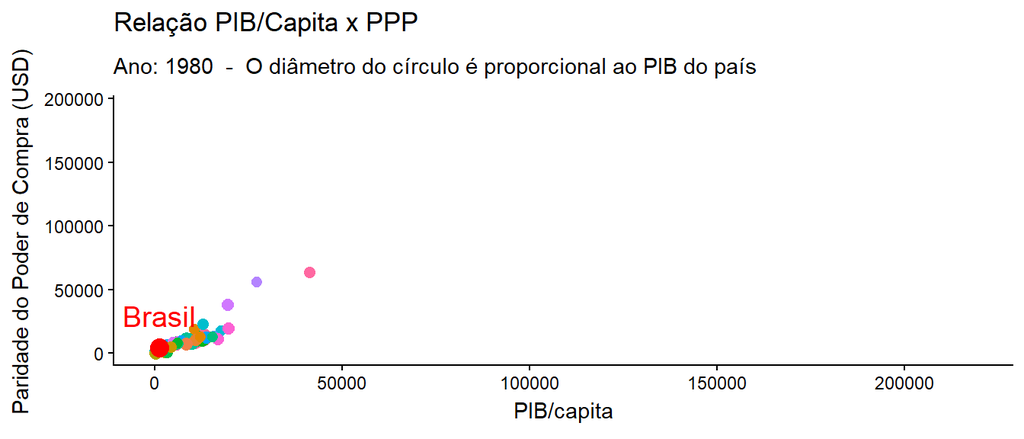

### 3.2. O Contexto Brasil

#### 3.2.1. Evolução do PIB/Capita e da Dívida Líquida do Brasil durante o período de Análise:

[figure not shown]

Para avaliar o evento ocorrido em 2015, em decorrência da crise iniciada entre 2013 e 2014, com sensível queda do PIB/capita no Brasil, foi realizada uma comparação entre o comportamento do PIB do Brasil com o mesmo indicador em relação ao mundo e aos países emergentes:

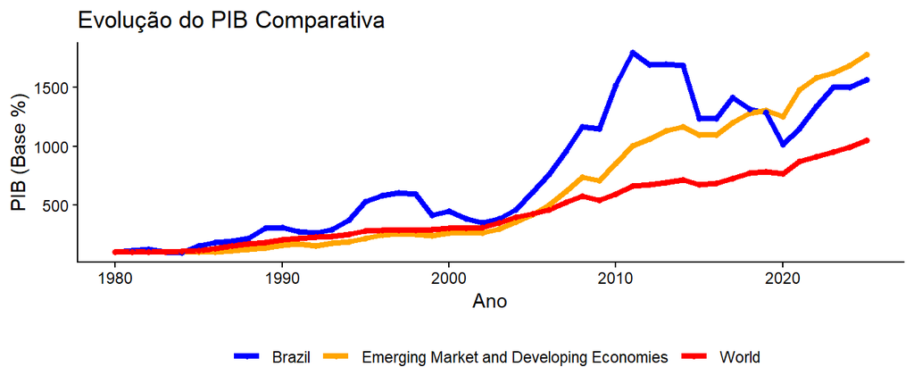

Este gráfico nos mostra que a economia do Brasil sofreu uma queda muito importante entre 2014 e 2015. A crise econômica que causou esta queda, também afetou os outros países, porém com menor intensidade. A evidência desta diferença pode ser observada no gráfico acima. Além disso, tanto os países emergentes, quanto o resto do mundo, conseguiram, em alguma medida, se recuperar dessa queda, o Brasil, no entanto, não só apresentou uma queda bem mais acentuada em seu PIB, como não conseguiu recuperar o tamanho de sua economia até o ano de 2025, último ano contemplado por este trabalho.

#### 3.2.2. Análise do Brasil dentro de um grupo com PIB/Capita semelhante

Para esta análise foram utilizados os dados mais recentes disponíveis na base de dados, ou seja, os valores apurados no ano de 2025. O PIB/Capita do Brasil no ano de 2025 foi de USD 10.685,68. Foi organizada uma tabela com os valores de PIB/Capita do Brasil em relação aos outros países do mundo conforme pode ser visto na tabela abaixo:

**Clique para mostrar a tabela**

PIB/Capita (USD)

[output not shown]

Em razão desse alto grau de dispersão entre os valores observados no mundo, foi selecionado um grupo de países com PIB/Capita entre USD 8.500 e 12.500, de maneira a tentar buscar países com esse indicador próximo ao do Brasil. A lista dos países selecionados está relacionada abaixo:

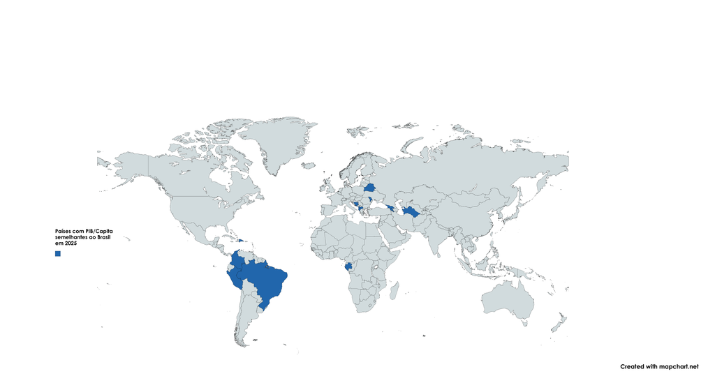

**Clique para mostrar a tabela**

**Países com PIB/Capita semelhantes ao Brasil em 2025**

| País | PIB | População | PPP | PIB/capita |
| --- | --- | --- | --- | --- |
| Grenada | 1.420 | 0.116 | 21546.66 | 12210.274 |
| Dominican Republic | 127.895 | 10.885 | 30407.19 | 11749.205 |
| Turkmenistan | 77.398 | 6.680 | 23323.03 | 11586.537 |
| Albania | 30.279 | 2.695 | 23497.74 | 11234.556 |
| Brazil | 2279.918 | 213.362 | 23380.97 | 10685.689 |
| St. Vincent and the Grenadines | 1.176 | 0.111 | 20777.49 | 10572.654 |
| North Macedonia, Republic of | 19.142 | 1.815 | 29773.44 | 10545.559 |
| Georgia | 38.216 | 3.694 | 31352.19 | 10346.094 |
| Belarus, Republic of | 92.766 | 9.087 | 34035.30 | 10208.724 |
| Peru | 341.025 | 34.409 | 19209.35 | 9910.942 |
| Dominica | 0.744 | 0.075 | 19516.55 | 9894.530 |
| Bosnia and Herzegovina | 32.962 | 3.445 | 22886.95 | 9567.697 |
| Armenia, Republic of | 29.243 | 3.071 | 24870.65 | 9520.965 |
| Gabon | 21.624 | 2.306 | 25000.27 | 9376.425 |
| Colombia | 457.410 | 53.048 | 22542.89 | 8622.574 |
| Moldova, Republic of | 20.342 | 2.381 | 19846.26 | 8542.376 |

Como pode ser observado, embora sejam países com PIB/Capita semelhantes, são países muito diferentes, principalmente em termos de população e valor absoluto de PIB. A média da população deste grupo é de 21,7 milhões de habitantes enquanto a mediana é de aproximadamente 3,3 milhões enquanto o Brasil apresenta uma população muito maior com cerca de 213 milhões e a mesma observação pode ser feita com relação ao PIB, o Brasil é uma economia muito maior que a dos outros países desse grupo:

**Clique para mostrar a tabela**

População (milhões de habitantes)

|  | Valor | Média | Mediana | Desvio Padrão |
| --- | --- | --- | --- | --- |
| Brasil | 213.36 | NA | NA | NA |
| Grupo | NA | 21.70 | 3.26 | 53.10 |

PIB (bilhões de USD)

|  | Valor | Média | Mediana | Desvio Padrão |
| --- | --- | --- | --- | --- |
| Brasil | 2,279.92 | NA | NA | NA |
| Grupo | NA | 223.22 | 31.62 | 563.49 |

#### 3.2.3. Análise do Brasil em Comparação aos outros países dos BRICS

A observação destas comparações nos leva à conclusão que o Brasil é um país singular e a comparação tanto com todos os países do mundo, quanto em grupo de de países com PIB/Capita semelhantes não se mostra adequada sob o ponto de vista da comparabilidade entre países. Uma outra forma de analisar a situação do país, seria fazer uma análise do ponto de vista geopolítico, comparando-o com o grupo formado por onze países denominados “BRICS”: Brasil, Rússia, Índia, China, África do Sul, Arábia Saudita, Egito, Emirados Árabes Unidos, Etiópia, Indonésia e Irã.

“O BRICS serve como foro de articulação político-diplomática e de cooperação de países do Sul Global nas mais diversas áreas. Não possui tratado constitutivo, orçamento próprio ou secretariado permanente.”

Abaixo está a lista completa desses países com seus respectivos indicadores referentes ao ano de 2025:

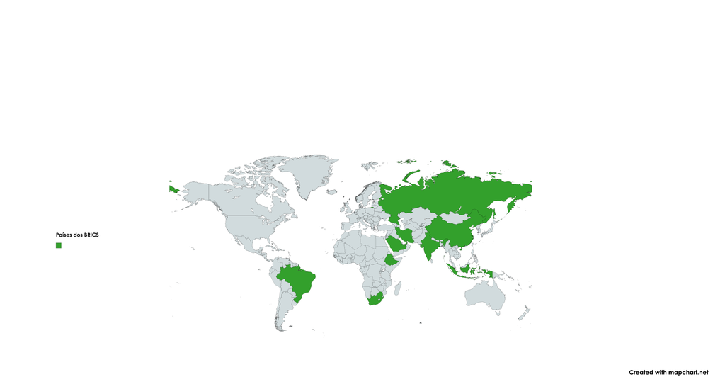

**Clique para mostrar a tabela**

**Países dos BRICS em 2025**

| País | PIB | População | PPP | PIB/capita |
| --- | --- | --- | --- | --- |
| United Arab Emirates | 571.643 | 11.380 | 83343.127 | 50231.644 |
| Saudi Arabia | 1276.943 | 36.006 | 75791.797 | 35464.445 |
| Russian Federation | 2587.938 | 143.997 | 50255.084 | 17972.117 |
| China, People's Republic of | 19626.247 | 1405.080 | 29352.032 | 13968.065 |
| Brazil | 2279.918 | 213.362 | 23380.975 | 10685.689 |
| South Africa | 427.141 | 63.101 | 16326.288 | 6769.156 |
| Indonesia | 1445.642 | 284.439 | 17745.531 | 5082.438 |
| Iran, Islamic Republic of | 371.196 | 87.057 | 21199.537 | 4263.822 |
| Egypt, Arab Republic of | 364.640 | 107.900 | 22184.595 | 3379.429 |
| India | 3916.312 | 1463.866 | 11789.254 | 2675.322 |
| Ethiopia, The Federal Democratic Republic of | 109.109 | 110.600 | 4498.549 | 986.516 |

No entanto, este grupo de países também é muito heterogêneo, como pode ser ser visto nas comparações entre o Brasil e o grupo nas tabelas abaixo que relacionam indicadores como PIB/Capita, PIB absoluto e População:

**Clique para mostrar a tabela**

PIB/Capita (USD)

[output not shown]

PIB (bilhões de USD)

|  | Valor | Média | Mediana | Desvio Padrão |
| --- | --- | --- | --- | --- |
| Brasil | 2,279.92 | NA | NA | NA |
| BRICS | NA | 2,997.88 | 1,276.94 | 5,639.81 |

População (milhões de habitantes)

|  | Valor | Média | Mediana | Desvio Padrão |
| --- | --- | --- | --- | --- |
| Brasil | 213.36 | NA | NA | NA |
| BRICS | NA | 356.98 | 110.60 | 538.46 |

## 4. Conclusões

Esta análise nos leva a algumas conclusões principais:

Existe uma relação bem próxima entre a riqueza de um país e o poder de compra de sua população, embora haja questões de como essa riqueza é distribuída, é importante saber que onde não tem riqueza não há o que distribuir.

Ao longo dos anos, pelo menos durante o período analisado, entre 1980 e 2025, os países em geral aumentaram sua riqueza e, consequentemente o poder de compra de sua população.

O Brasil é um país com características muito singulares, não permitindo uma boa comparação com nenhum dos países do mundo e nem tampouco com um grupo específico.

Embora o Brasil tenha experimentado a mesma evolução de riqueza que os outros países do mundo, a crise de 2014 causou uma perda importante em sua riqueza. Essa crise, somada à pandemia de 2020, causaram uma queda no PIB brasileiro tão significativa que até o ano de 2025 o país não havia recuperado o tamanho de sua economia dos tempos pré crise.

A Dívida líquida do Brasil em relação ao PIB está em uma trajetória de subida, principalmente após a crise econômica de 2014 e que não apresenta sinais de reversão de sua trajetória.

## 5. Uso de IA

Neste trabalho foram utilizadas ferramentas de inteligência artificial (Copilot e Gemini) para o desenvolvimento de códigos e ajuda nos comandos do software de markdown (Quarto), além das referências indicadas.

## 6. Referências

- Fundo Monetário Internacionalhttps://data.imf.org/en/Data-Explorer?datasetUrn=IMF.RES:WEO(9.0.0))
- BRICS https://brics.br/pt-br/sobre-o-brics/perguntas-frequentes-sobre-o-brics?activeAccordion=c16d356f-d7fa-4cf2-89fc-f39a37b6191a
- Wickham H, Averick M, Bryan J, Chang W, McGowan LD, François R, Grolemund G, Hayes A, Henry L, Hester J, Kuhn M, Pedersen TL, Miller E, Bache SM, Müller K, Ooms J, Robinson D, Seidel DP, Spinu V, Takahashi K, Vaughan D, Wilke C, Woo K, Yutani H (2019). “Welcome to the tidyverse.” *Journal of Open Source Software*, *4*(43), 1686. doi:10.21105/joss.01686 https://doi.org/10.21105/joss.01686.
- Wickham H, Hester J, Bryan J (2026). *readr: Read Rectangular Text Data*. doi:10.32614/CRAN.package.readr https://doi.org/10.32614/CRAN.package.readr. R package version 2.2.0, https://CRAN.R-project.org/package=readr.
- Wickham H, François R, Henry L, Müller K, Vaughan D (2026). *dplyr: A Grammar of Data Manipulation*. doi:10.32614/CRAN.package.dplyr https://doi.org/10.32614/CRAN.package.dplyr. R package version 1.2.1, https://CRAN.R-project.org/package=dplyr.
- H. Wickham. ggplot2: Elegant Graphics for Data Analysis. Springer-Verlag New York, 2016.
- Iannone R, Cheng J, Schloerke B, Haughton S, Hughes E, Lauer A, François R, Seo J, Brevoort K, Roy O (2026). *gt: Easily Create Presentation-Ready Display Tables*. doi:10.32614/CRAN.package.gt https://doi.org/10.32614/CRAN.package.gt. R package version 1.3.0, https://CRAN.R-project.org/package=gt.
- Xie Y (2025). *knitr: A General-Purpose Package for Dynamic Report Generation in R*. R package version 1.51, https://yihui.org/knitr/.

  Yihui Xie (2015) Dynamic Documents with R and knitr. 2nd edition. Chapman and Hall/CRC. ISBN 978-1498716963

  Yihui Xie (2014) knitr: A Comprehensive Tool for Reproducible Research in R. In Victoria Stodden, Friedrich Leisch and Roger D. Peng, editors, Implementing Reproducible Computational Research. Chapman and Hall/CRC. ISBN 978-1466561595
- Pedersen T, Robinson D (2025). *gganimate: A Grammar of Animated Graphics*. doi:10.32614/CRAN.package.gganimate https://doi.org/10.32614/CRAN.package.gganimate. R package version 1.0.11, https://CRAN.R-project.org/package=gganimate.
- RStudio 2026.05.1+225 “Golden Wattle” Release (89e0c7da7b7b806fc5701ecb567f993716d8cfdc, 2026-06-07) for windows Mozilla/5.0 (Windows NT 10.0; Win64; x64) AppleWebKit/537.36 (KHTML, like Gecko) RStudio/2026.05.1+225 Chrome/146.0.7680.216 Electron/41.5.0 Safari/537.36, Quarto 1.9.36
- WICKHAM H., ÇETINKAYA-RUNDEL, M., GROLEMUND, G. (2023) R for Data Science, O’Reilly, 2 edição. Disponível em https://r4ds.hadley.nz/
- Guia do Quarto: https://quarto.org/docs/guide/.
- Repositório de Imagens: https://www.pexels.com/pt-br/collections/money-cfuxoe7/